# Risk Factor Analysis

## Outcome Variable

**Outcome Variable:** stunted

## Predictor Variables

**Intervention Variable:** predexfd6

**Adjustment Set:**

- arm
- sex
- brthmon
- W_mage
- meducyrs
- feducyrs
- hhwealth_quart
- hfoodsec
- W_mhtcm
- W_mwtkg
- W_mbmi
- vagbrth
- W_gagebrth
- W_birthwt
- W_birthlen
- W_nrooms
- W_nchldlt5
- month
- W_parity
- impfloor
- impsan
- safeh20
- delta_W_mage
- delta_meducyrs
- delta_feducyrs
- delta_hhwealth_quart
- delta_hfoodsec
- delta_W_mhtcm
- delta_W_mwtkg
- delta_W_mbmi
- delta_vagbrth
- delta_W_gagebrth
- delta_W_birthwt
- delta_W_birthlen
- delta_W_nrooms
- delta_W_nchldlt5
- delta_month
- delta_W_parity
- delta_impfloor
- delta_impsan
- delta_safeh20

## Stratifying Variables

The analysis was stratified on these variable(s):

- agecat
- studyid
- country

## Data Summary

| agecat | studyid | country | predexfd6 | stunted | n_cell | n |
| --- | --- | --- | --- | --- | --- | --- |
| Birth | ki0047075b-MAL-ED | BANGLADESH | 1 | 0 | 60 | 205 |
| Birth | ki0047075b-MAL-ED | BANGLADESH | 1 | 1 | 12 | 205 |
| Birth | ki0047075b-MAL-ED | BANGLADESH | 0 | 0 | 109 | 205 |
| Birth | ki0047075b-MAL-ED | BANGLADESH | 0 | 1 | 24 | 205 |
| Birth | ki0047075b-MAL-ED | BRAZIL | 1 | 0 | 4 | 60 |
| Birth | ki0047075b-MAL-ED | BRAZIL | 1 | 1 | 2 | 60 |
| Birth | ki0047075b-MAL-ED | BRAZIL | 0 | 0 | 47 | 60 |
| Birth | ki0047075b-MAL-ED | BRAZIL | 0 | 1 | 7 | 60 |
| Birth | ki0047075b-MAL-ED | INDIA | 1 | 0 | 2 | 39 |
| Birth | ki0047075b-MAL-ED | INDIA | 1 | 1 | 2 | 39 |
| Birth | ki0047075b-MAL-ED | INDIA | 0 | 0 | 29 | 39 |
| Birth | ki0047075b-MAL-ED | INDIA | 0 | 1 | 6 | 39 |
| Birth | ki0047075b-MAL-ED | NEPAL | 1 | 0 | 3 | 24 |
| Birth | ki0047075b-MAL-ED | NEPAL | 1 | 1 | 0 | 24 |
| Birth | ki0047075b-MAL-ED | NEPAL | 0 | 0 | 20 | 24 |
| Birth | ki0047075b-MAL-ED | NEPAL | 0 | 1 | 1 | 24 |
| Birth | ki0047075b-MAL-ED | PERU | 1 | 0 | 66 | 213 |
| Birth | ki0047075b-MAL-ED | PERU | 1 | 1 | 7 | 213 |
| Birth | ki0047075b-MAL-ED | PERU | 0 | 0 | 121 | 213 |
| Birth | ki0047075b-MAL-ED | PERU | 0 | 1 | 19 | 213 |
| Birth | ki0047075b-MAL-ED | SOUTH AFRICA | 1 | 0 | 1 | 91 |
| Birth | ki0047075b-MAL-ED | SOUTH AFRICA | 1 | 1 | 0 | 91 |
| Birth | ki0047075b-MAL-ED | SOUTH AFRICA | 0 | 0 | 82 | 91 |
| Birth | ki0047075b-MAL-ED | SOUTH AFRICA | 0 | 1 | 8 | 91 |
| Birth | ki0047075b-MAL-ED | TANZANIA, UNITED REPUBLIC OF | 1 | 0 | 0 | 113 |
| Birth | ki0047075b-MAL-ED | TANZANIA, UNITED REPUBLIC OF | 1 | 1 | 0 | 113 |
| Birth | ki0047075b-MAL-ED | TANZANIA, UNITED REPUBLIC OF | 0 | 0 | 92 | 113 |
| Birth | ki0047075b-MAL-ED | TANZANIA, UNITED REPUBLIC OF | 0 | 1 | 21 | 113 |
| Birth | ki1000108-CMC-V-BCS-2002 | INDIA | 1 | 0 | 7 | 7 |
| Birth | ki1000108-CMC-V-BCS-2002 | INDIA | 1 | 1 | 0 | 7 |

[output cut: 170 more lines]

The following strata were considered:

- agecat: 24 months, studyid: ki0047075b-MAL-ED, country: BANGLADESH
- agecat: 24 months, studyid: ki0047075b-MAL-ED, country: BRAZIL
- agecat: 24 months, studyid: ki0047075b-MAL-ED, country: INDIA
- agecat: 24 months, studyid: ki0047075b-MAL-ED, country: NEPAL
- agecat: 24 months, studyid: ki0047075b-MAL-ED, country: PERU
- agecat: 24 months, studyid: ki0047075b-MAL-ED, country: SOUTH AFRICA
- agecat: 24 months, studyid: ki0047075b-MAL-ED, country: TANZANIA, UNITED REPUBLIC OF
- agecat: 24 months, studyid: ki1000108-CMC-V-BCS-2002, country: INDIA
- agecat: 24 months, studyid: ki1000108-IRC, country: INDIA
- agecat: 24 months, studyid: ki1000109-EE, country: PAKISTAN
- agecat: 24 months, studyid: ki1017093b-PROVIDE, country: BANGLADESH
- agecat: 24 months, studyid: ki1101329-Keneba, country: GAMBIA
- agecat: 24 months, studyid: ki1113344-GMS-Nepal, country: NEPAL
- agecat: 24 months, studyid: ki1148112-LCNI-5, country: MALAWI
- agecat: 24 months, studyid: kiGH5241-JiVitA-3, country: BANGLADESH
- agecat: 24 months, studyid: kiGH5241-JiVitA-4, country: BANGLADESH
- agecat: 6 months, studyid: ki0047075b-MAL-ED, country: BANGLADESH
- agecat: 6 months, studyid: ki0047075b-MAL-ED, country: BRAZIL
- agecat: 6 months, studyid: ki0047075b-MAL-ED, country: INDIA
- agecat: 6 months, studyid: ki0047075b-MAL-ED, country: NEPAL
- agecat: 6 months, studyid: ki0047075b-MAL-ED, country: PERU
- agecat: 6 months, studyid: ki0047075b-MAL-ED, country: SOUTH AFRICA
- agecat: 6 months, studyid: ki0047075b-MAL-ED, country: TANZANIA, UNITED REPUBLIC OF
- agecat: 6 months, studyid: ki1000108-CMC-V-BCS-2002, country: INDIA
- agecat: 6 months, studyid: ki1000108-IRC, country: INDIA
- agecat: 6 months, studyid: ki1000109-EE, country: PAKISTAN
- agecat: 6 months, studyid: ki1000304b-SAS-CompFeed, country: INDIA
- agecat: 6 months, studyid: ki1000304b-SAS-FoodSuppl, country: INDIA
- agecat: 6 months, studyid: ki1017093b-PROVIDE, country: BANGLADESH
- agecat: 6 months, studyid: ki1101329-Keneba, country: GAMBIA
- agecat: 6 months, studyid: ki1113344-GMS-Nepal, country: NEPAL
- agecat: 6 months, studyid: ki1148112-LCNI-5, country: MALAWI
- agecat: 6 months, studyid: kiGH5241-JiVitA-3, country: BANGLADESH
- agecat: 6 months, studyid: kiGH5241-JiVitA-4, country: BANGLADESH
- agecat: Birth, studyid: ki0047075b-MAL-ED, country: BANGLADESH
- agecat: Birth, studyid: ki0047075b-MAL-ED, country: BRAZIL
- agecat: Birth, studyid: ki0047075b-MAL-ED, country: INDIA
- agecat: Birth, studyid: ki0047075b-MAL-ED, country: NEPAL
- agecat: Birth, studyid: ki0047075b-MAL-ED, country: PERU
- agecat: Birth, studyid: ki0047075b-MAL-ED, country: SOUTH AFRICA
- agecat: Birth, studyid: ki0047075b-MAL-ED, country: TANZANIA, UNITED REPUBLIC OF
- agecat: Birth, studyid: ki1000108-CMC-V-BCS-2002, country: INDIA
- agecat: Birth, studyid: ki1000108-IRC, country: INDIA
- agecat: Birth, studyid: ki1000109-EE, country: PAKISTAN
- agecat: Birth, studyid: ki1000304b-SAS-CompFeed, country: INDIA
- agecat: Birth, studyid: ki1017093b-PROVIDE, country: BANGLADESH
- agecat: Birth, studyid: ki1101329-Keneba, country: GAMBIA
- agecat: Birth, studyid: ki1113344-GMS-Nepal, country: NEPAL
- agecat: Birth, studyid: kiGH5241-JiVitA-3, country: BANGLADESH
- agecat: Birth, studyid: kiGH5241-JiVitA-4, country: BANGLADESH

### Dropped Strata

Some strata were dropped due to rare outcomes:

- agecat: Birth, studyid: ki0047075b-MAL-ED, country: BRAZIL
- agecat: Birth, studyid: ki0047075b-MAL-ED, country: INDIA
- agecat: Birth, studyid: ki0047075b-MAL-ED, country: NEPAL
- agecat: Birth, studyid: ki0047075b-MAL-ED, country: SOUTH AFRICA
- agecat: Birth, studyid: ki0047075b-MAL-ED, country: TANZANIA, UNITED REPUBLIC OF
- agecat: Birth, studyid: ki1000108-CMC-V-BCS-2002, country: INDIA
- agecat: Birth, studyid: ki1000108-IRC, country: INDIA
- agecat: Birth, studyid: ki1000109-EE, country: PAKISTAN
- agecat: 6 months, studyid: ki0047075b-MAL-ED, country: BRAZIL
- agecat: 6 months, studyid: ki0047075b-MAL-ED, country: INDIA
- agecat: 6 months, studyid: ki0047075b-MAL-ED, country: NEPAL
- agecat: 6 months, studyid: ki0047075b-MAL-ED, country: SOUTH AFRICA
- agecat: 6 months, studyid: ki0047075b-MAL-ED, country: TANZANIA, UNITED REPUBLIC OF
- agecat: 6 months, studyid: ki1000108-CMC-V-BCS-2002, country: INDIA
- agecat: 6 months, studyid: ki1000108-IRC, country: INDIA
- agecat: 6 months, studyid: ki1000109-EE, country: PAKISTAN
- agecat: 6 months, studyid: ki1000304b-SAS-FoodSuppl, country: INDIA
- agecat: 24 months, studyid: ki0047075b-MAL-ED, country: BRAZIL
- agecat: 24 months, studyid: ki0047075b-MAL-ED, country: INDIA
- agecat: 24 months, studyid: ki0047075b-MAL-ED, country: NEPAL
- agecat: 24 months, studyid: ki0047075b-MAL-ED, country: SOUTH AFRICA
- agecat: 24 months, studyid: ki0047075b-MAL-ED, country: TANZANIA, UNITED REPUBLIC OF
- agecat: 24 months, studyid: ki1000108-CMC-V-BCS-2002, country: INDIA
- agecat: 24 months, studyid: ki1000108-IRC, country: INDIA
- agecat: 24 months, studyid: ki1000109-EE, country: PAKISTAN

## Methods Detail

We’re interested in the causal parameters $E[Y_a]$ for all values of $a \in \mathcal{A}$. These parameters represent the mean outcome if, possibly contrary to fact, we intervened to set all units to have $A=a$. Under the randomization and positivity assumptions, these are identified by the statistical parameters $\psi_a=E_W[E_{Y|A,W}(Y|A=a,W)]$. In addition, we’re interested in the mean of $Y$, $E[Y]$ under no intervention (the observed mean). We will estimate these parameters by using SuperLearner to fit the relevant likelihood factors – $E_{Y|A,W}(Y|A=a,W)$ and $p(A=a|W)$, and then updating our likelihood fit using a joint TMLE.

For unadjusted analyses ($W=\{\}$), initial likelihoods were estimated using Lrnr_glm to estimate the simple $E(Y|A)$ and Lrnr_mean to estimate $p(A)$. For adjusted analyses, a small library containing Lrnr_glmnet, Lrnr_xgboost, and Lrnr_mean was used.

Having estimated these parameters, we will then use the delta method to estimate relative risks and attributable risks relative to a prespecified baseline level of $A$.

# Results Detail

## Results Plots

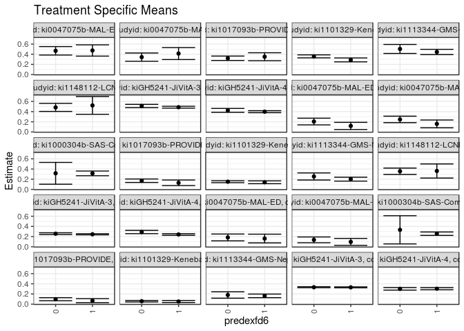

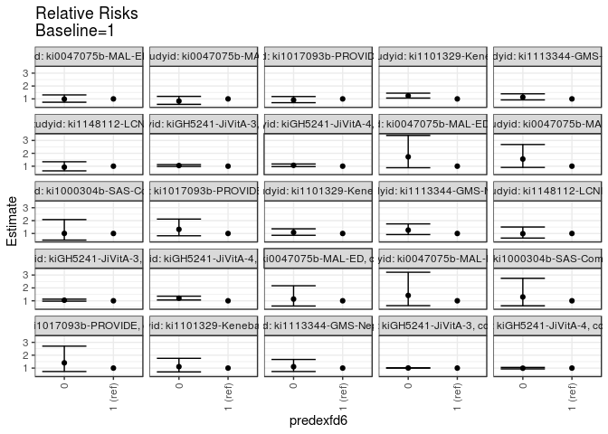

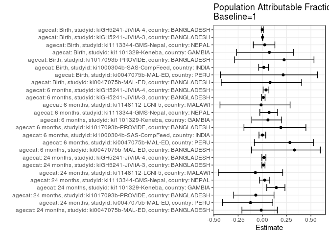

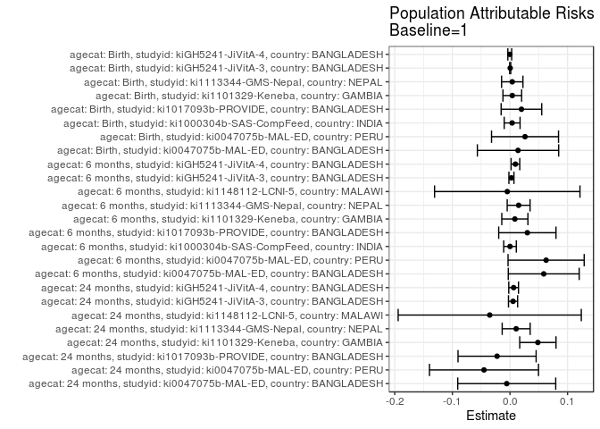

## Results Table

### Parameter: TSM

| agecat | studyid | country | intervention_level | baseline_level | estimate | ci_lower | ci_upper |
| --- | --- | --- | --- | --- | --- | --- | --- |
| Birth | ki0047075b-MAL-ED | BANGLADESH | 1 | NA | 0.1616162 | 0.0756488 | 0.2475836 |
| Birth | ki0047075b-MAL-ED | BANGLADESH | 0 | NA | 0.1833492 | 0.1160870 | 0.2506114 |
| Birth | ki0047075b-MAL-ED | PERU | 1 | NA | 0.0958904 | 0.0281876 | 0.1635932 |
| Birth | ki0047075b-MAL-ED | PERU | 0 | NA | 0.1357143 | 0.0788490 | 0.1925796 |
| Birth | ki1000304b-SAS-CompFeed | INDIA | 1 | NA | 0.2572254 | 0.2236819 | 0.2907690 |
| Birth | ki1000304b-SAS-CompFeed | INDIA | 0 | NA | 0.3333333 | 0.0564891 | 0.6101775 |
| Birth | ki1017093b-PROVIDE | BANGLADESH | 1 | NA | 0.0691188 | 0.0291812 | 0.1090564 |
| Birth | ki1017093b-PROVIDE | BANGLADESH | 0 | NA | 0.0971947 | 0.0673476 | 0.1270418 |
| Birth | ki1101329-Keneba | GAMBIA | 1 | NA | 0.0522656 | 0.0324781 | 0.0720531 |
| Birth | ki1101329-Keneba | GAMBIA | 0 | NA | 0.0580413 | 0.0429332 | 0.0731495 |
| Birth | ki1113344-GMS-Nepal | NEPAL | 1 | NA | 0.1629834 | 0.1275497 | 0.1984170 |
| Birth | ki1113344-GMS-Nepal | NEPAL | 0 | NA | 0.1803990 | 0.1175536 | 0.2432445 |
| Birth | kiGH5241-JiVitA-3 | BANGLADESH | 1 | NA | 0.3306197 | 0.3213682 | 0.3398713 |
| Birth | kiGH5241-JiVitA-3 | BANGLADESH | 0 | NA | 0.3328037 | 0.3230703 | 0.3425372 |
| Birth | kiGH5241-JiVitA-4 | BANGLADESH | 1 | NA | 0.3039222 | 0.2824410 | 0.3254034 |
| Birth | kiGH5241-JiVitA-4 | BANGLADESH | 0 | NA | 0.3012615 | 0.2760454 | 0.3264776 |
| 6 months | ki0047075b-MAL-ED | BANGLADESH | 1 | NA | 0.1188449 | 0.0482724 | 0.1894173 |
| 6 months | ki0047075b-MAL-ED | BANGLADESH | 0 | NA | 0.2052581 | 0.1394218 | 0.2710943 |
| 6 months | ki0047075b-MAL-ED | PERU | 1 | NA | 0.1586268 | 0.0821016 | 0.2351521 |
| 6 months | ki0047075b-MAL-ED | PERU | 0 | NA | 0.2468486 | 0.1831520 | 0.3105452 |
| 6 months | ki1000304b-SAS-CompFeed | INDIA | 1 | NA | 0.3139842 | 0.2679102 | 0.3600581 |
| 6 months | ki1000304b-SAS-CompFeed | INDIA | 0 | NA | 0.3157895 | 0.1014523 | 0.5301266 |
| 6 months | ki1017093b-PROVIDE | BANGLADESH | 1 | NA | 0.1287444 | 0.0735573 | 0.1839314 |
| 6 months | ki1017093b-PROVIDE | BANGLADESH | 0 | NA | 0.1699267 | 0.1358403 | 0.2040132 |
| 6 months | ki1101329-Keneba | GAMBIA | 1 | NA | 0.1393135 | 0.1119243 | 0.1667026 |
| 6 months | ki1101329-Keneba | GAMBIA | 0 | NA | 0.1508302 | 0.1317767 | 0.1698838 |
| 6 months | ki1113344-GMS-Nepal | NEPAL | 1 | NA | 0.2006642 | 0.1625571 | 0.2387712 |
| 6 months | ki1113344-GMS-Nepal | NEPAL | 0 | NA | 0.2533923 | 0.1837188 | 0.3230658 |
| 6 months | ki1148112-LCNI-5 | MALAWI | 1 | NA | 0.3612939 | 0.2225331 | 0.5000547 |
| 6 months | ki1148112-LCNI-5 | MALAWI | 0 | NA | 0.3558210 | 0.2930913 | 0.4185506 |
| 6 months | kiGH5241-JiVitA-3 | BANGLADESH | 1 | NA | 0.2457185 | 0.2347865 | 0.2566506 |
| 6 months | kiGH5241-JiVitA-3 | BANGLADESH | 0 | NA | 0.2565399 | 0.2386526 | 0.2744271 |
| 6 months | kiGH5241-JiVitA-4 | BANGLADESH | 1 | NA | 0.2416739 | 0.2257403 | 0.2576075 |
| 6 months | kiGH5241-JiVitA-4 | BANGLADESH | 0 | NA | 0.2899349 | 0.2574744 | 0.3223955 |
| 24 months | ki0047075b-MAL-ED | BANGLADESH | 1 | NA | 0.4738863 | 0.3632517 | 0.5845210 |
| 24 months | ki0047075b-MAL-ED | BANGLADESH | 0 | NA | 0.4670009 | 0.3839272 | 0.5500746 |
| 24 months | ki0047075b-MAL-ED | PERU | 1 | NA | 0.4132582 | 0.2952204 | 0.5312959 |
| 24 months | ki0047075b-MAL-ED | PERU | 0 | NA | 0.3431189 | 0.2621091 | 0.4241287 |
| 24 months | ki1017093b-PROVIDE | BANGLADESH | 1 | NA | 0.3510842 | 0.2728506 | 0.4293178 |
| 24 months | ki1017093b-PROVIDE | BANGLADESH | 0 | NA | 0.3205823 | 0.2770155 | 0.3641491 |
| 24 months | ki1101329-Keneba | GAMBIA | 1 | NA | 0.2886334 | 0.2502025 | 0.3270643 |
| 24 months | ki1101329-Keneba | GAMBIA | 0 | NA | 0.3579953 | 0.3286857 | 0.3873049 |
| 24 months | ki1113344-GMS-Nepal | NEPAL | 1 | NA | 0.4445412 | 0.3932984 | 0.4957841 |
| 24 months | ki1113344-GMS-Nepal | NEPAL | 0 | NA | 0.5034321 | 0.4150346 | 0.5918296 |
| 24 months | ki1148112-LCNI-5 | MALAWI | 1 | NA | 0.5218959 | 0.3472867 | 0.6965051 |
| 24 months | ki1148112-LCNI-5 | MALAWI | 0 | NA | 0.4828667 | 0.4036529 | 0.5620806 |
| 24 months | kiGH5241-JiVitA-3 | BANGLADESH | 1 | NA | 0.4867603 | 0.4680854 | 0.5054353 |
| 24 months | kiGH5241-JiVitA-3 | BANGLADESH | 0 | NA | 0.5107930 | 0.4787646 | 0.5428213 |
| 24 months | kiGH5241-JiVitA-4 | BANGLADESH | 1 | NA | 0.3987271 | 0.3792097 | 0.4182444 |
| 24 months | kiGH5241-JiVitA-4 | BANGLADESH | 0 | NA | 0.4247208 | 0.3866143 | 0.4628272 |

### Parameter: E(Y)

| agecat | studyid | country | intervention_level | baseline_level | estimate | ci_lower | ci_upper |
| --- | --- | --- | --- | --- | --- | --- | --- |
| Birth | ki0047075b-MAL-ED | BANGLADESH | NA | NA | 0.1756098 | 0.1233973 | 0.2278222 |
| Birth | ki0047075b-MAL-ED | PERU | NA | NA | 0.1220657 | 0.0779993 | 0.1661322 |
| Birth | ki1000304b-SAS-CompFeed | INDIA | NA | NA | 0.2609890 | 0.2179233 | 0.3040547 |
| Birth | ki1017093b-PROVIDE | BANGLADESH | NA | NA | 0.0890538 | 0.0649864 | 0.1131212 |
| Birth | ki1101329-Keneba | GAMBIA | NA | NA | 0.0563079 | 0.0442416 | 0.0683742 |
| Birth | ki1113344-GMS-Nepal | NEPAL | NA | NA | 0.1669627 | 0.1361293 | 0.1977961 |
| Birth | kiGH5241-JiVitA-3 | BANGLADESH | NA | NA | 0.3310735 | 0.3218922 | 0.3402548 |
| Birth | kiGH5241-JiVitA-4 | BANGLADESH | NA | NA | 0.3035714 | 0.2824097 | 0.3247332 |
| 6 months | ki0047075b-MAL-ED | BANGLADESH | NA | NA | 0.1774892 | 0.1281103 | 0.2268680 |
| 6 months | ki0047075b-MAL-ED | PERU | NA | NA | 0.2214022 | 0.1718784 | 0.2709260 |
| 6 months | ki1000304b-SAS-CompFeed | INDIA | NA | NA | 0.3140704 | 0.2712850 | 0.3568557 |
| 6 months | ki1017093b-PROVIDE | BANGLADESH | NA | NA | 0.1589404 | 0.1297581 | 0.1881227 |
| 6 months | ki1101329-Keneba | GAMBIA | NA | NA | 0.1477987 | 0.1318701 | 0.1637274 |
| 6 months | ki1113344-GMS-Nepal | NEPAL | NA | NA | 0.2157221 | 0.1812209 | 0.2502233 |
| 6 months | ki1148112-LCNI-5 | MALAWI | NA | NA | 0.3566176 | 0.2995882 | 0.4136471 |
| 6 months | kiGH5241-JiVitA-3 | BANGLADESH | NA | NA | 0.2482578 | 0.2382387 | 0.2582768 |
| 6 months | kiGH5241-JiVitA-4 | BANGLADESH | NA | NA | 0.2511704 | 0.2362353 | 0.2661055 |
| 24 months | ki0047075b-MAL-ED | BANGLADESH | NA | NA | 0.4682927 | 0.3998183 | 0.5367670 |
| 24 months | ki0047075b-MAL-ED | PERU | NA | NA | 0.3681592 | 0.3013164 | 0.4350020 |
| 24 months | ki1017093b-PROVIDE | BANGLADESH | NA | NA | 0.3287197 | 0.2903909 | 0.3670485 |
| 24 months | ki1101329-Keneba | GAMBIA | NA | NA | 0.3370787 | 0.3132517 | 0.3609056 |
| 24 months | ki1113344-GMS-Nepal | NEPAL | NA | NA | 0.4553192 | 0.4102488 | 0.5003895 |
| 24 months | ki1148112-LCNI-5 | MALAWI | NA | NA | 0.4867725 | 0.4153250 | 0.5582200 |
| 24 months | kiGH5241-JiVitA-3 | BANGLADESH | NA | NA | 0.4921384 | 0.4750959 | 0.5091808 |
| 24 months | kiGH5241-JiVitA-4 | BANGLADESH | NA | NA | 0.4050965 | 0.3867240 | 0.4234689 |

### Parameter: RR

| agecat | studyid | country | intervention_level | baseline_level | estimate | ci_lower | ci_upper |
| --- | --- | --- | --- | --- | --- | --- | --- |
| Birth | ki0047075b-MAL-ED | BANGLADESH | 1 | 1 | 1.0000000 | 1.0000000 | 1.000000 |
| Birth | ki0047075b-MAL-ED | BANGLADESH | 0 | 1 | 1.1344734 | 0.5937428 | 2.167655 |
| Birth | ki0047075b-MAL-ED | PERU | 1 | 1 | 1.0000000 | 1.0000000 | 1.000000 |
| Birth | ki0047075b-MAL-ED | PERU | 0 | 1 | 1.4153061 | 0.6227136 | 3.216714 |
| Birth | ki1000304b-SAS-CompFeed | INDIA | 1 | 1 | 1.0000000 | 1.0000000 | 1.000000 |
| Birth | ki1000304b-SAS-CompFeed | INDIA | 0 | 1 | 1.2958801 | 0.6113712 | 2.746785 |
| Birth | ki1017093b-PROVIDE | BANGLADESH | 1 | 1 | 1.0000000 | 1.0000000 | 1.000000 |
| Birth | ki1017093b-PROVIDE | BANGLADESH | 0 | 1 | 1.4061986 | 0.7311456 | 2.704515 |
| Birth | ki1101329-Keneba | GAMBIA | 1 | 1 | 1.0000000 | 1.0000000 | 1.000000 |
| Birth | ki1101329-Keneba | GAMBIA | 0 | 1 | 1.1105078 | 0.7016994 | 1.757487 |
| Birth | ki1113344-GMS-Nepal | NEPAL | 1 | 1 | 1.0000000 | 1.0000000 | 1.000000 |
| Birth | ki1113344-GMS-Nepal | NEPAL | 0 | 1 | 1.1068555 | 0.7339723 | 1.669176 |
| Birth | kiGH5241-JiVitA-3 | BANGLADESH | 1 | 1 | 1.0000000 | 1.0000000 | 1.000000 |
| Birth | kiGH5241-JiVitA-3 | BANGLADESH | 0 | 1 | 1.0066057 | 0.9935584 | 1.019824 |
| Birth | kiGH5241-JiVitA-4 | BANGLADESH | 1 | 1 | 1.0000000 | 1.0000000 | 1.000000 |
| Birth | kiGH5241-JiVitA-4 | BANGLADESH | 0 | 1 | 0.9912453 | 0.9363894 | 1.049315 |
| 6 months | ki0047075b-MAL-ED | BANGLADESH | 1 | 1 | 1.0000000 | 1.0000000 | 1.000000 |
| 6 months | ki0047075b-MAL-ED | BANGLADESH | 0 | 1 | 1.7271091 | 0.8804835 | 3.387804 |
| 6 months | ki0047075b-MAL-ED | PERU | 1 | 1 | 1.0000000 | 1.0000000 | 1.000000 |
| 6 months | ki0047075b-MAL-ED | PERU | 0 | 1 | 1.5561588 | 0.9025864 | 2.682990 |
| 6 months | ki1000304b-SAS-CompFeed | INDIA | 1 | 1 | 1.0000000 | 1.0000000 | 1.000000 |
| 6 months | ki1000304b-SAS-CompFeed | INDIA | 0 | 1 | 1.0057497 | 0.4866253 | 2.078668 |
| 6 months | ki1017093b-PROVIDE | BANGLADESH | 1 | 1 | 1.0000000 | 1.0000000 | 1.000000 |
| 6 months | ki1017093b-PROVIDE | BANGLADESH | 0 | 1 | 1.3198771 | 0.8226518 | 2.117634 |
| 6 months | ki1101329-Keneba | GAMBIA | 1 | 1 | 1.0000000 | 1.0000000 | 1.000000 |
| 6 months | ki1101329-Keneba | GAMBIA | 0 | 1 | 1.0826681 | 0.8605289 | 1.362151 |
| 6 months | ki1113344-GMS-Nepal | NEPAL | 1 | 1 | 1.0000000 | 1.0000000 | 1.000000 |
| 6 months | ki1113344-GMS-Nepal | NEPAL | 0 | 1 | 1.2627679 | 0.9141991 | 1.744240 |
| 6 months | ki1148112-LCNI-5 | MALAWI | 1 | 1 | 1.0000000 | 1.0000000 | 1.000000 |
| 6 months | ki1148112-LCNI-5 | MALAWI | 0 | 1 | 0.9848519 | 0.6452228 | 1.503253 |
| 6 months | kiGH5241-JiVitA-3 | BANGLADESH | 1 | 1 | 1.0000000 | 1.0000000 | 1.000000 |
| 6 months | kiGH5241-JiVitA-3 | BANGLADESH | 0 | 1 | 1.0440396 | 0.9680490 | 1.125995 |
| 6 months | kiGH5241-JiVitA-4 | BANGLADESH | 1 | 1 | 1.0000000 | 1.0000000 | 1.000000 |
| 6 months | kiGH5241-JiVitA-4 | BANGLADESH | 0 | 1 | 1.1996950 | 1.0603875 | 1.357304 |
| 24 months | ki0047075b-MAL-ED | BANGLADESH | 1 | 1 | 1.0000000 | 1.0000000 | 1.000000 |
| 24 months | ki0047075b-MAL-ED | BANGLADESH | 0 | 1 | 0.9854703 | 0.7409774 | 1.310636 |
| 24 months | ki0047075b-MAL-ED | PERU | 1 | 1 | 1.0000000 | 1.0000000 | 1.000000 |
| 24 months | ki0047075b-MAL-ED | PERU | 0 | 1 | 0.8302774 | 0.5771921 | 1.194335 |
| 24 months | ki1017093b-PROVIDE | BANGLADESH | 1 | 1 | 1.0000000 | 1.0000000 | 1.000000 |
| 24 months | ki1017093b-PROVIDE | BANGLADESH | 0 | 1 | 0.9131209 | 0.7051609 | 1.182411 |
| 24 months | ki1101329-Keneba | GAMBIA | 1 | 1 | 1.0000000 | 1.0000000 | 1.000000 |
| 24 months | ki1101329-Keneba | GAMBIA | 0 | 1 | 1.2403113 | 1.0635501 | 1.446450 |
| 24 months | ki1113344-GMS-Nepal | NEPAL | 1 | 1 | 1.0000000 | 1.0000000 | 1.000000 |
| 24 months | ki1113344-GMS-Nepal | NEPAL | 0 | 1 | 1.1324756 | 0.9211399 | 1.392298 |
| 24 months | ki1148112-LCNI-5 | MALAWI | 1 | 1 | 1.0000000 | 1.0000000 | 1.000000 |
| 24 months | ki1148112-LCNI-5 | MALAWI | 0 | 1 | 0.9252165 | 0.6371285 | 1.343568 |
| 24 months | kiGH5241-JiVitA-3 | BANGLADESH | 1 | 1 | 1.0000000 | 1.0000000 | 1.000000 |
| 24 months | kiGH5241-JiVitA-3 | BANGLADESH | 0 | 1 | 1.0493727 | 0.9796037 | 1.124111 |
| 24 months | kiGH5241-JiVitA-4 | BANGLADESH | 1 | 1 | 1.0000000 | 1.0000000 | 1.000000 |
| 24 months | kiGH5241-JiVitA-4 | BANGLADESH | 0 | 1 | 1.0651917 | 0.9684651 | 1.171579 |

### Parameter: PAR

| agecat | studyid | country | intervention_level | baseline_level | estimate | ci_lower | ci_upper |
| --- | --- | --- | --- | --- | --- | --- | --- |
| Birth | ki0047075b-MAL-ED | BANGLADESH | 1 | NA | 0.0139936 | -0.0566090 | 0.0845962 |
| Birth | ki0047075b-MAL-ED | PERU | 1 | NA | 0.0261753 | -0.0319940 | 0.0843446 |
| Birth | ki1000304b-SAS-CompFeed | INDIA | 1 | NA | 0.0037636 | -0.0100156 | 0.0175428 |
| Birth | ki1017093b-PROVIDE | BANGLADESH | 1 | NA | 0.0199350 | -0.0153250 | 0.0551951 |
| Birth | ki1101329-Keneba | GAMBIA | 1 | NA | 0.0040423 | -0.0121817 | 0.0202663 |
| Birth | ki1113344-GMS-Nepal | NEPAL | 1 | NA | 0.0039793 | -0.0145656 | 0.0225243 |
| Birth | kiGH5241-JiVitA-3 | BANGLADESH | 1 | NA | 0.0004538 | -0.0005012 | 0.0014088 |
| Birth | kiGH5241-JiVitA-4 | BANGLADESH | 1 | NA | -0.0003508 | -0.0036649 | 0.0029633 |
| 6 months | ki0047075b-MAL-ED | BANGLADESH | 1 | NA | 0.0586443 | -0.0029318 | 0.1202204 |
| 6 months | ki0047075b-MAL-ED | PERU | 1 | NA | 0.0627754 | -0.0033223 | 0.1288730 |
| 6 months | ki1000304b-SAS-CompFeed | INDIA | 1 | NA | 0.0000862 | -0.0108674 | 0.0110398 |
| 6 months | ki1017093b-PROVIDE | BANGLADESH | 1 | NA | 0.0301960 | -0.0195315 | 0.0799236 |
| 6 months | ki1101329-Keneba | GAMBIA | 1 | NA | 0.0084853 | -0.0142009 | 0.0311715 |
| 6 months | ki1113344-GMS-Nepal | NEPAL | 1 | NA | 0.0150579 | -0.0047844 | 0.0349002 |
| 6 months | ki1148112-LCNI-5 | MALAWI | 1 | NA | -0.0046762 | -0.1309186 | 0.1215662 |
| 6 months | kiGH5241-JiVitA-3 | BANGLADESH | 1 | NA | 0.0025392 | -0.0018348 | 0.0069132 |
| 6 months | kiGH5241-JiVitA-4 | BANGLADESH | 1 | NA | 0.0094965 | 0.0019747 | 0.0170183 |
| 24 months | ki0047075b-MAL-ED | BANGLADESH | 1 | NA | -0.0055937 | -0.0906622 | 0.0794749 |
| 24 months | ki0047075b-MAL-ED | PERU | 1 | NA | -0.0450989 | -0.1397674 | 0.0495696 |
| 24 months | ki1017093b-PROVIDE | BANGLADESH | 1 | NA | -0.0223645 | -0.0901738 | 0.0454448 |
| 24 months | ki1101329-Keneba | GAMBIA | 1 | NA | 0.0484452 | 0.0169387 | 0.0799518 |
| 24 months | ki1113344-GMS-Nepal | NEPAL | 1 | NA | 0.0107779 | -0.0134948 | 0.0350506 |
| 24 months | ki1148112-LCNI-5 | MALAWI | 1 | NA | -0.0351234 | -0.1941156 | 0.1238688 |
| 24 months | kiGH5241-JiVitA-3 | BANGLADESH | 1 | NA | 0.0053781 | -0.0025751 | 0.0133312 |
| 24 months | kiGH5241-JiVitA-4 | BANGLADESH | 1 | NA | 0.0063694 | -0.0020811 | 0.0148199 |

### Parameter: PAF

| agecat | studyid | country | intervention_level | baseline_level | estimate | ci_lower | ci_upper |
| --- | --- | --- | --- | --- | --- | --- | --- |
| Birth | ki0047075b-MAL-ED | BANGLADESH | 1 | NA | 0.0796857 | -0.4239757 | 0.4052017 |
| Birth | ki0047075b-MAL-ED | PERU | 1 | NA | 0.2144362 | -0.4318688 | 0.5690175 |
| Birth | ki1000304b-SAS-CompFeed | INDIA | 1 | NA | 0.0144204 | -0.0378960 | 0.0640998 |
| Birth | ki1017093b-PROVIDE | BANGLADESH | 1 | NA | 0.2238536 | -0.2868660 | 0.5318835 |
| Birth | ki1101329-Keneba | GAMBIA | 1 | NA | 0.0717896 | -0.2657046 | 0.3192925 |
| Birth | ki1113344-GMS-Nepal | NEPAL | 1 | NA | 0.0238337 | -0.0937339 | 0.1287637 |
| Birth | kiGH5241-JiVitA-3 | BANGLADESH | 1 | NA | 0.0013707 | -0.0015191 | 0.0042521 |
| Birth | kiGH5241-JiVitA-4 | BANGLADESH | 1 | NA | -0.0011555 | -0.0121310 | 0.0097009 |
| 6 months | ki0047075b-MAL-ED | BANGLADESH | 1 | NA | 0.3304106 | -0.1128380 | 0.5971112 |
| 6 months | ki0047075b-MAL-ED | PERU | 1 | NA | 0.2835354 | -0.0828466 | 0.5259518 |
| 6 months | ki1000304b-SAS-CompFeed | INDIA | 1 | NA | 0.0002744 | -0.0352245 | 0.0345560 |
| 6 months | ki1017093b-PROVIDE | BANGLADESH | 1 | NA | 0.1899833 | -0.1898287 | 0.4485534 |
| 6 months | ki1101329-Keneba | GAMBIA | 1 | NA | 0.0574111 | -0.1092506 | 0.1990324 |
| 6 months | ki1113344-GMS-Nepal | NEPAL | 1 | NA | 0.0698025 | -0.0264395 | 0.1570205 |
| 6 months | ki1148112-LCNI-5 | MALAWI | 1 | NA | -0.0131127 | -0.4368335 | 0.2856532 |
| 6 months | kiGH5241-JiVitA-3 | BANGLADESH | 1 | NA | 0.0102281 | -0.0075532 | 0.0276956 |
| 6 months | kiGH5241-JiVitA-4 | BANGLADESH | 1 | NA | 0.0378091 | 0.0075705 | 0.0671264 |
| 24 months | ki0047075b-MAL-ED | BANGLADESH | 1 | NA | -0.0119448 | -0.2108810 | 0.1543081 |
| 24 months | ki0047075b-MAL-ED | PERU | 1 | NA | -0.1224985 | -0.4115735 | 0.1073771 |
| 24 months | ki1017093b-PROVIDE | BANGLADESH | 1 | NA | -0.0680352 | -0.2956724 | 0.1196084 |
| 24 months | ki1101329-Keneba | GAMBIA | 1 | NA | 0.1437208 | 0.0449731 | 0.2322582 |
| 24 months | ki1113344-GMS-Nepal | NEPAL | 1 | NA | 0.0236711 | -0.0311806 | 0.0756051 |
| 24 months | ki1148112-LCNI-5 | MALAWI | 1 | NA | -0.0721557 | -0.4541612 | 0.2094977 |
| 24 months | kiGH5241-JiVitA-3 | BANGLADESH | 1 | NA | 0.0109279 | -0.0053626 | 0.0269545 |
| 24 months | kiGH5241-JiVitA-4 | BANGLADESH | 1 | NA | 0.0157231 | -0.0053066 | 0.0363130 |